# Introducción a la Ciencia de Datos en R - CPS

Ramiro Oliverio Fernández, Hernán Escudero

2019-09-27

### Data Wrangling

Vamos a avanzar en aprender cómo manipular bases de datos con funciones del paquete `tidyverse`.

Para esto, primero instalamos y cargamos la librería.

```r
#install.packages("tidyverse")
library(tidyverse)
```

Volvemos a cargar el dataset de *radares* como hicimos en la clase anterior. Pueden reemplazar esta línea con el set de datos que quieran trabajar!

```r
radares <- read.csv("http://cdn.buenosaires.gob.ar/datosabiertos/datasets/flujo-vehicular-por-radares-ausa/flujo-vehicular-por-radares-2019.csv", header=TRUE, sep=',', dec='.')
```

### dplyr

Es uno de los componentes de todos los paquetes que integran tidyverse (no hace falta llamar a este paquete específicamente, ya lo hicimos cuando trajimos `tidyverse`).

#### select()

Esta función nos permite seleccionar ciertas columnas del dataset con el que estamos trabajando. Es importante para bases con una alta dimensionalidad (ya que puede haber muchas columnas que no nos interesen o que las descartamos para que las operaciones sean más rápidas)

Vemos primero las columnas del DF

```r
names(radares)
```

```
##  [1] "X"                "fecha"            "hora"
##  [4] "autopista_nombre" "disp_nombre"      "disp_ubicacion"
##  [7] "seccion_sentido"  "lat"              "long"
## [10] "cantidad"
```

Hacemos la selección indicando las columnas con las que me quiero quedar

```r
radares_reducido <- select(radares, fecha, hora, cantidad)

head(radares_reducido)
```

```
##        fecha hora cantidad
## 1 2019-01-01    0      618
## 2 2019-01-01    0      797
## 3 2019-01-01    0       66
## 4 2019-01-01    0      857
## 5 2019-01-01    0      861
## 6 2019-01-01    0      834
```

La selección puede ser indicando con el operador `:` para seleccionar las columnas en un rango de aparición. Hacemos la selección indicando las columnas con las que me quiero quedar

```r
radares_reducido <- select(radares, autopista_nombre:cantidad)

head(radares_reducido)
```

```
##   autopista_nombre     disp_nombre disp_ubicacion seccion_sentido
## 1    AU 4  Lugones   RD165 Dorrego           4.74               A
## 2    AU 4  Lugones    RD166 Ombues           5.50               A
## 3    AU 4  Lugones RD168 Juramento           7.20               A
## 4    AU 4  Lugones    RD169 Monroe           8.11               A
## 5    AU 4  Lugones   RD170 Udaondo           8.68               A
## 6    AU 4  Lugones      RD171 Esma           9.90               A
##         lat      long cantidad
## 1 -34.56336 -58.41529      618
## 2 -34.56044 -58.41908      797
## 3 -34.54977 -58.43602       66
## 4 -34.54629 -58.44224      857
## 5 -34.54293 -58.44901      861
## 6 -34.53767 -58.45967      834
```

La selección puede realizarse para excluir una variable

```r
radares_reducido <- select(radares, -disp_nombre)

head(radares_reducido)
```

```
##   X      fecha hora autopista_nombre disp_ubicacion seccion_sentido
## 1 0 2019-01-01    0    AU 4  Lugones           4.74               A
## 2 1 2019-01-01    0    AU 4  Lugones           5.50               A
## 3 2 2019-01-01    0    AU 4  Lugones           7.20               A
## 4 3 2019-01-01    0    AU 4  Lugones           8.11               A
## 5 4 2019-01-01    0    AU 4  Lugones           8.68               A
## 6 5 2019-01-01    0    AU 4  Lugones           9.90               A
##         lat      long cantidad
## 1 -34.56336 -58.41529      618
## 2 -34.56044 -58.41908      797
## 3 -34.54977 -58.43602       66
## 4 -34.54629 -58.44224      857
## 5 -34.54293 -58.44901      861
## 6 -34.53767 -58.45967      834
```

#### filter()

Esta función nos permite filtrar los registros de nuestro dataset con una cierta condición. En la clase anterior, vimos una función similar que es `subset()`. Por ejemplo, si queremos seleccionar las observaciones de la autopista Lugones

```r
radares_filtrado <- filter(radares, autopista_nombre=='AU 4  Lugones')

head(radares_filtrado)
```

```
##   X      fecha hora autopista_nombre     disp_nombre disp_ubicacion
## 1 0 2019-01-01    0    AU 4  Lugones   RD165 Dorrego           4.74
## 2 1 2019-01-01    0    AU 4  Lugones    RD166 Ombues           5.50
## 3 2 2019-01-01    0    AU 4  Lugones RD168 Juramento           7.20
## 4 3 2019-01-01    0    AU 4  Lugones    RD169 Monroe           8.11
## 5 4 2019-01-01    0    AU 4  Lugones   RD170 Udaondo           8.68
## 6 5 2019-01-01    0    AU 4  Lugones      RD171 Esma           9.90
##   seccion_sentido       lat      long cantidad
## 1               A -34.56336 -58.41529      618
## 2               A -34.56044 -58.41908      797
## 3               A -34.54977 -58.43602       66
## 4               A -34.54629 -58.44224      857
## 5               A -34.54293 -58.44901      861
## 6               A -34.53767 -58.45967      834
```

Podemos usar otros operadores lógicos (el “or”, expresado con `|`) para filtrar la base

```r
radares_filtrado <- filter(radares, autopista_nombre=='AU 4  Lugones' | autopista_nombre=='AU 5 Cantilo')

head(radares_filtrado)
```

```
##   X      fecha hora autopista_nombre     disp_nombre disp_ubicacion
## 1 0 2019-01-01    0    AU 4  Lugones   RD165 Dorrego           4.74
## 2 1 2019-01-01    0    AU 4  Lugones    RD166 Ombues           5.50
## 3 2 2019-01-01    0    AU 4  Lugones RD168 Juramento           7.20
## 4 3 2019-01-01    0    AU 4  Lugones    RD169 Monroe           8.11
## 5 4 2019-01-01    0    AU 4  Lugones   RD170 Udaondo           8.68
## 6 5 2019-01-01    0    AU 4  Lugones      RD171 Esma           9.90
##   seccion_sentido       lat      long cantidad
## 1               A -34.56336 -58.41529      618
## 2               A -34.56044 -58.41908      797
## 3               A -34.54977 -58.43602       66
## 4               A -34.54629 -58.44224      857
## 5               A -34.54293 -58.44901      861
## 6               A -34.53767 -58.45967      834
```

Incluimos un ejemplo con otros operadores lógicos. Comentadas están otras formas de hacer la misma operación, lo que cambia es su sintaxis.

```r
radares_filtrado <- filter(radares, autopista_nombre!='AU 4  Lugones' & cantidad>50)
#radares_filtrado <- filter(radares, autopista_nombre!='AU 4  Lugones', cantidad>50)
#radares_filtrado <- filter(radares, !(autopista_nombre=='AU 4  Lugones') & cantidad>50)

head(radares_filtrado)
```

```
##    X      fecha hora  autopista_nombre          disp_nombre disp_ubicacion
## 1  6 2019-01-01    0      AU 5 Cantilo       RD180 Encalada           7.40
## 2  7 2019-01-01    0      AU 5 Cantilo RD181 Ciudad Univer.           8.45
## 3  8 2019-01-01    0      AU 5 Cantilo        RD182 Labruna           8.70
## 4  9 2019-01-01    0      AU 5 Cantilo   RD183 Centro Naval           9.90
## 5 10 2019-01-01    0 AU 9 de Julio Sur     RD126 Osv.Cruz B           0.16
## 6 11 2019-01-01    0 AU 9 de Julio Sur      RD129 Olavarria           1.45
##   seccion_sentido       lat      long cantidad
## 1               B -34.54778 -58.43848      233
## 2               B -34.54362 -58.44640      807
## 3               B -34.54230 -58.44869      635
## 4               B -34.53709 -58.45916      656
## 5               B -34.65136 -58.37266      379
## 6               B -34.64076 -58.37651      472
```

#### arrange()

La función `arrange()` ordena nuestro dataframe por las columnas que les pasemos.

```r
radares_ordenado <- arrange(radares, cantidad)
head(radares_ordenado)
```

```
##      X      fecha hora autopista_nombre   disp_nombre disp_ubicacion
## 1 1360 2019-01-03   10    AU Dellepiane RD111 Ramal 9           0.18
## 2 1416 2019-01-03   12    AU Dellepiane RD111 Ramal 9           0.18
## 3 1444 2019-01-03   13    AU Dellepiane RD111 Ramal 9           0.18
## 4 1472 2019-01-03   14    AU Dellepiane RD111 Ramal 9           0.18
## 5 1500 2019-01-03   15    AU Dellepiane RD111 Ramal 9           0.18
## 6 1556 2019-01-03   17    AU Dellepiane RD111 Ramal 9           0.18
##   seccion_sentido       lat      long cantidad
## 1               B -34.65061 -58.46677        0
## 2               B -34.65061 -58.46677        0
## 3               B -34.65061 -58.46677        0
## 4               B -34.65061 -58.46677        0
## 5               B -34.65061 -58.46677        0
## 6               B -34.65061 -58.46677        0
```

Si se agregan más columnas, se van usando para ordenar el dataframe según su orden de aparición

```r
radares_ordenado <- arrange(radares, cantidad, autopista_nombre)
head(radares_ordenado)
```

```
##       X      fecha hora  autopista_nombre      disp_nombre disp_ubicacion
## 1 13041 2019-01-19    5     AU 4  Lugones  RD168 Juramento           7.20
## 2 18414 2019-02-01    0 AU 9 de Julio Sur RD125 Osv.Cruz A           0.16
## 3 18438 2019-02-01    1 AU 9 de Julio Sur RD125 Osv.Cruz A           0.16
## 4 18462 2019-02-01    2 AU 9 de Julio Sur RD125 Osv.Cruz A           0.16
## 5 20142 2019-02-04    0 AU 9 de Julio Sur RD125 Osv.Cruz A           0.16
## 6 20147 2019-02-04    0 AU 9 de Julio Sur     RD130 Suarez           1.16
##   seccion_sentido       lat      long cantidad
## 1               A -34.54977 -58.43602        0
## 2               A -34.65134 -58.37255        0
## 3               A -34.65134 -58.37255        0
## 4               A -34.65134 -58.37255        0
## 5               A -34.65134 -58.37255        0
## 6               A -34.63940 -58.37635        0
```

```r
radares_ordenado <- arrange(radares, desc(cantidad))
head(radares_ordenado)
```

```
##       X      fecha hora autopista_nombre   disp_nombre disp_ubicacion
## 1 49279 2019-03-22    7    AU 4  Lugones  RD169 Monroe           8.11
## 2 59507 2019-04-12    7    AU 4  Lugones  RD169 Monroe           8.11
## 3 81009 2019-05-23    7    AU 4  Lugones  RD169 Monroe           8.11
## 4 55475 2019-04-05    7    AU 4  Lugones  RD169 Monroe           8.11
## 5 49281 2019-03-22    7    AU 4  Lugones    RD171 Esma           9.90
## 6 49280 2019-03-22    7    AU 4  Lugones RD170 Udaondo           8.68
##   seccion_sentido       lat      long cantidad
## 1               A -34.54629 -58.44224    10397
## 2               A -34.54629 -58.44224    10340
## 3               A -34.54629 -58.44224    10321
## 4               A -34.54629 -58.44224    10279
## 5               A -34.53767 -58.45967    10252
## 6               A -34.54293 -58.44901    10230
```

#### mutate()

Esta función nos permite generar columnas adicionales en el dataframe utilizando la información de las columnas ya existentes. Podemos usar los operadores aritméticos para crear variables con ``mutate()`. Aquí vamos a usar la función `substring()` con la cual extraemos una parte de un valor `string`

```r
radares <- mutate(radares,
                             anio = substr(fecha, 1, 4),
                             mes = substr(fecha, 6, 7),
                  dia = substr(fecha, 9, 10))

head(radares)
```

```
##   X      fecha hora autopista_nombre     disp_nombre disp_ubicacion
## 1 0 2019-01-01    0    AU 4  Lugones   RD165 Dorrego           4.74
## 2 1 2019-01-01    0    AU 4  Lugones    RD166 Ombues           5.50
## 3 2 2019-01-01    0    AU 4  Lugones RD168 Juramento           7.20
## 4 3 2019-01-01    0    AU 4  Lugones    RD169 Monroe           8.11
## 5 4 2019-01-01    0    AU 4  Lugones   RD170 Udaondo           8.68
## 6 5 2019-01-01    0    AU 4  Lugones      RD171 Esma           9.90
##   seccion_sentido       lat      long cantidad anio mes dia
## 1               A -34.56336 -58.41529      618 2019  01  01
## 2               A -34.56044 -58.41908      797 2019  01  01
## 3               A -34.54977 -58.43602       66 2019  01  01
## 4               A -34.54629 -58.44224      857 2019  01  01
## 5               A -34.54293 -58.44901      861 2019  01  01
## 6               A -34.53767 -58.45967      834 2019  01  01
```

#### summarise()

Esta función se suele usar con `group_by` ya que genera un output con la función que se incluya dentro, con `group_by` obtendremos una para cada grupo. Vamos a verlo en ejemplos.

```r
#aquí solo vamos a ver la medida calculada
summarise(radares, promedio = mean(cantidad))
```

```
##   promedio
## 1 2856.372
```

```r
#acá agrupamos el dataframe por los valores únicos de 'autopista_nombre'
agrupado <- group_by(radares, autopista_nombre)

summarise(agrupado, promedio_autopista = mean(cantidad))
```

```
## # A tibble: 4 x 2
##   autopista_nombre  promedio_autopista
##   <fct>                          <dbl>
## 1 AU 4  Lugones                  4361.
## 2 AU 5 Cantilo                   3515.
## 3 AU 9 de Julio Sur              2469.
## 4 AU Dellepiane                  2043.
```

Se pueden agregar más columnas en el agrupamiento, por ejemplo

```r
agrupado <- group_by(radares, anio, mes)

summarise(agrupado, promedio = median(cantidad))
```

```
## # A tibble: 8 x 3
## # Groups:   anio [1]
##   anio  mes   promedio
##   <chr> <chr>    <dbl>
## 1 2019  01       2324.
## 2 2019  02       2505
## 3 2019  03       2487
## 4 2019  04       2592
## 5 2019  05       2709
## 6 2019  06       2629
## 7 2019  07       2755
## 8 2019  08       2840
```

Podemos usar muchas otras funciones dentro de `summarise()`, como por ejemplo `sum()` (aplica una suma),`sd()` (desvío estándar), `IQR()` (rango intercuartil), `min()`, `max()`, `n()` y `n_distinct()`. Estos dos últimos son utilizados para contar y resultan bastante útiles.

Recomendamos leer toda la [documentación de dplyr](https://www.rdocumentation.org/packages/dplyr/versions/0.7.8), o directamente la de [tidyverse](https://www.tidyverse.org/packages/) para poder explorar todas las funciones que hay en los mismos.

#### Operador “pipe”: `%>%`

El operador *pipe* relaciona entidades, toma lo referenciado a la izquierda del operador y lo transforma con los comandos de la derecha. El principal beneficio de este operador es hacer el código mucho más simple y fácil de interpretar. También nos ahorra de crear muchos objetos que no vamos a volver a utilizar. Todas las funciones que vimos anteriormente se suelen utilizar en cadenadas con pipes, el cual se expresa con el operador `%>%`. Por ejemplo, en el siguiente código llamamos al dataframe, filtramos por el mes “01”, agrupamos por `autopista_nombre`, usamos ``summarise()` para hacer una suma de la variable `cantidad` (que se va a hacer sobre los grupos realizados en el `group_by`), para luego ordenarlo de forma descendiente y mostrar las primeras 5 filas con `head()`

```r
radares %>%
    filter(mes == '01') %>%
    group_by(autopista_nombre) %>%
    summarise(total = sum(cantidad)) %>%
    arrange(desc(total)) %>%
    head(5)
```

```
## # A tibble: 4 x 2
##   autopista_nombre     total
##   <fct>                <int>
## 1 AU 9 de Julio Sur 15166635
## 2 AU 4  Lugones     12784136
## 3 AU Dellepiane     11823688
## 4 AU 5 Cantilo       7798419
```

#### rename()

Con esta función cambiamos el nombre de la columna. El primer parámetro es el nuevo nombre de la columna, y el segundo parámetro el nombre de la columna que queremos cambiar.

```r
radares %>%
  rename(nombre_autopista = autopista_nombre) %>%
  head(5)
```

```
##   X      fecha hora nombre_autopista     disp_nombre disp_ubicacion
## 1 0 2019-01-01    0    AU 4  Lugones   RD165 Dorrego           4.74
## 2 1 2019-01-01    0    AU 4  Lugones    RD166 Ombues           5.50
## 3 2 2019-01-01    0    AU 4  Lugones RD168 Juramento           7.20
## 4 3 2019-01-01    0    AU 4  Lugones    RD169 Monroe           8.11
## 5 4 2019-01-01    0    AU 4  Lugones   RD170 Udaondo           8.68
##   seccion_sentido       lat      long cantidad anio mes dia
## 1               A -34.56336 -58.41529      618 2019  01  01
## 2               A -34.56044 -58.41908      797 2019  01  01
## 3               A -34.54977 -58.43602       66 2019  01  01
## 4               A -34.54629 -58.44224      857 2019  01  01
## 5               A -34.54293 -58.44901      861 2019  01  01
```

```r
#vemos que en el output cambia el nombre de la columna, pero para guardarlo, lo tenemos que asignar al objeto que teníamos.

radares <- radares %>%
  rename(nombre_autopista = autopista_nombre)

#chequeamos
names(radares)
```

```
##  [1] "X"                "fecha"            "hora"
##  [4] "nombre_autopista" "disp_nombre"      "disp_ubicacion"
##  [7] "seccion_sentido"  "lat"              "long"
## [10] "cantidad"         "anio"             "mes"
## [13] "dia"
```

#### case_when()

Esta función nos permite crear una variable definiendo una condición en base a los valores de las columnas preestablecidas. Sino se cumple la condición, la variable toma valor *NA*. Los parámetros que toma la función son las distintas condiciones. En este caso creamos una variable indicando el trimestre del registro, la variable que se crea puede tener una combinación usando otras variables (por ejemplo operadores aritméticos sobre la variable `cantidad`)

```r
radares <- radares %>%
  mutate(variable_creada = case_when((mes == "01")|(mes == "02")|(mes == "03")   ~ '1er-trimestre',
                                 (mes == "04")|(mes == "05")|(mes == "06")   ~ '2do-trimestre',
                                 (mes == "07")|(mes == "08")|(mes == "09")   ~ '3er-trimestre',
                                 (mes == "10")|(mes == "11")|(mes == "12")   ~ '4to-trimestre'))
head(radares)
```

```
##   X      fecha hora nombre_autopista     disp_nombre disp_ubicacion
## 1 0 2019-01-01    0    AU 4  Lugones   RD165 Dorrego           4.74
## 2 1 2019-01-01    0    AU 4  Lugones    RD166 Ombues           5.50
## 3 2 2019-01-01    0    AU 4  Lugones RD168 Juramento           7.20
## 4 3 2019-01-01    0    AU 4  Lugones    RD169 Monroe           8.11
## 5 4 2019-01-01    0    AU 4  Lugones   RD170 Udaondo           8.68
## 6 5 2019-01-01    0    AU 4  Lugones      RD171 Esma           9.90
##   seccion_sentido       lat      long cantidad anio mes dia
## 1               A -34.56336 -58.41529      618 2019  01  01
## 2               A -34.56044 -58.41908      797 2019  01  01
## 3               A -34.54977 -58.43602       66 2019  01  01
## 4               A -34.54629 -58.44224      857 2019  01  01
## 5               A -34.54293 -58.44901      861 2019  01  01
## 6               A -34.53767 -58.45967      834 2019  01  01
##   variable_creada
## 1   1er-trimestre
## 2   1er-trimestre
## 3   1er-trimestre
## 4   1er-trimestre
## 5   1er-trimestre
## 6   1er-trimestre
```

#### Joins

Vamos a crear un dataframe ficticio con la longitud de las autopistas para joinearlo con nuestro dataset de `radares` con el que venimos trabajando. Luego lo vamos a joinear con radares, utilizando radares como dataframe “left”.

```r
longitud_autopistas <- data.frame(nombre_autopista = c("AU 4  Lugones","AU 5 Cantilo","AU 9 de Julio Sur", "AU Dellepiane"),
                            longitud_kilometros = c(52,36,65.8, 19))

#con el punto indico que joinee por lo anterior
#acá, cómo se hace el left_join llamando a ambos dataframes
#left_join(radares, longitud_autopistas, by='nombre_autopista')

#y acá haciendolo con pipe, el "." indica que llama a lo anterior
radares <- radares %>%
  left_join(.,longitud_autopistas, by = "nombre_autopista")
head(radares)
```

```
##   X      fecha hora nombre_autopista     disp_nombre disp_ubicacion
## 1 0 2019-01-01    0    AU 4  Lugones   RD165 Dorrego           4.74
## 2 1 2019-01-01    0    AU 4  Lugones    RD166 Ombues           5.50
## 3 2 2019-01-01    0    AU 4  Lugones RD168 Juramento           7.20
## 4 3 2019-01-01    0    AU 4  Lugones    RD169 Monroe           8.11
## 5 4 2019-01-01    0    AU 4  Lugones   RD170 Udaondo           8.68
## 6 5 2019-01-01    0    AU 4  Lugones      RD171 Esma           9.90
##   seccion_sentido       lat      long cantidad anio mes dia
## 1               A -34.56336 -58.41529      618 2019  01  01
## 2               A -34.56044 -58.41908      797 2019  01  01
## 3               A -34.54977 -58.43602       66 2019  01  01
## 4               A -34.54629 -58.44224      857 2019  01  01
## 5               A -34.54293 -58.44901      861 2019  01  01
## 6               A -34.53767 -58.45967      834 2019  01  01
##   variable_creada longitud_kilometros
## 1   1er-trimestre                  52
## 2   1er-trimestre                  52
## 3   1er-trimestre                  52
## 4   1er-trimestre                  52
## 5   1er-trimestre                  52
## 6   1er-trimestre                  52
```

### tidyr

Este paquete, parte también de `tidyverse`, está pensado para poner en formato `tidy` (concepto que se ve en el paper que está en la clase anterior) a los datos. La `tidy data` se logra si:

- Cada columna es una variable
- Cada fila es una observación
- Cada celda es un valor singular

Recomendamos la lectura de las [guías de datos de GCBA](https://datosgcba.github.io/guia-datos/) donde hay una serie de formatos, estándares y recomendaciones como ejemplos de `tidy data`.

Cheatsheet de `tidyr`, algunos paquetes tienen cheatsheets de este estilo (que resumen las funcionalidades del paquete):

[figure not shown]

Vamos a ver dos funciones: ``spread()` y `gather()`

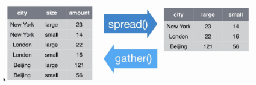

Armamos una nueva tabla para mostrar las funciones:

```r
cantidad_autopista_mes <- radares %>%
    group_by(nombre_autopista, mes) %>%
    summarise(total = sum(cantidad))
```

#### Spread

```r
datos_spread <- cantidad_autopista_mes %>%
  spread(.,
  key = nombre_autopista,    #variable cuyos valores van a pasar a ser los nombres de columnas
  value = total) #los valores con los que se llenan las celdas, los que van a ser "esparcidos"

datos_spread
```

```
## # A tibble: 8 x 5
##   mes   `AU 4  Lugones` `AU 5 Cantilo` `AU 9 de Julio Sur` `AU Dellepiane`
##   <chr>           <int>          <int>               <int>           <int>
## 1 01           12784136        7798419            15166635        11823688
## 2 02           14863872        9305973            15130620         6586823
## 3 03           14284135        7842808            15692268        10954523
## 4 04           14691879        5966548            15415653        11323952
## 5 05           17640900        6289719            16276627         9555616
## 6 06           17120818        5492279            15740914        11425619
## 7 07           16671836        6306686            17433512        11834926
## 8 08           19984427        9040960            18648488        13810258
```

#### Gather

`gather()` es la función opuesta, nos permite revertir el resultado (o la podemos aplicar directamente, depende de cómo estén estructurandos nuestros datos)

```r
datos_gather <- datos_spread %>%
  gather(.,
   key   = nombre_autopista,   #variable que toma los nombres de las columnas
   value = total,  #variable que toma los valores de las columnas
   2:5)             #le indico que columnas juntar

datos_gather
```

```
## # A tibble: 32 x 3
##    mes   nombre_autopista    total
##    <chr> <chr>               <int>
##  1 01    AU 4  Lugones    12784136
##  2 02    AU 4  Lugones    14863872
##  3 03    AU 4  Lugones    14284135
##  4 04    AU 4  Lugones    14691879
##  5 05    AU 4  Lugones    17640900
##  6 06    AU 4  Lugones    17120818
##  7 07    AU 4  Lugones    16671836
##  8 08    AU 4  Lugones    19984427
##  9 01    AU 5 Cantilo      7798419
## 10 02    AU 5 Cantilo      9305973
## # ... with 22 more rows
```

### bind_rows, cbind() y rbind()

Esta función de `dplyr` permite apilar dos dataframes en uno solo. Es similar a `rbind()` (función muy conocida, que tiene su versión para concatenar columnas llamada `cbind()`), pero la diferencia radica en que `bind_rows()` permite combinar dos dataframes con diferente número de columnas, mientras que `rbind` tira error en ese caso. ``bind_rows()```` asigna *NA* a las filas de un dataframe donde el valor no es provisto por una columna de mismo nombre de otro dataframe.

```r
radares2 <- radares %>%
  filter(cantidad > 100)

nrow(radares)
```

```
## [1] 141055
```

```r
nrow(radares2)
```

```
## [1] 137606
```

```r
union <- bind_rows(radares, radares2)
nrow(union)
```

```
## [1] 278661
```

```r
nrow(radares)+nrow(radares2)
```

```
## [1] 278661
```

```r
#veamos un ejemplo de qué pasa sino tienen las mismas columnas:
a <- data.frame(a = 1:2, b = 3:4, c = 5:6)
b <- data.frame(a = 7:8, b = 2:3, c = 3:4, d = 8:9)
#ejecutando esto, rbind tira error
#rbind(a, b)
#bind_rows concatena los dataframes, sin valores de "d" para el objeto "a"
bind_rows(a, b)
```

```
##   a b c  d
## 1 1 3 5 NA
## 2 2 4 6 NA
## 3 7 2 3  8
## 4 8 3 4  9
```

Ejemplo de ``cbind()`. Ejemplo extraido de http://www.datasciencemadesimple.com/cbind-in-r/, recomendamos webs como estas (por ejemplo r-bloggers, rstatisticsblog, las van a ir conociendo a medida que googleen diferentes funciones!)

```r
#Creamos dos dataframes
df1 = data.frame(name = c("Rahul","joe","Adam","Brendon"), married_year = c(2016,2015,2016,2008))
df2 = data.frame(Birth_place = c("Delhi","Seattle","London","Moscow"), Birth_year = c(1988,1990,1989,1984))

cbinded_df<-cbind(df1,df2)
cbinded_df
```

```
##      name married_year Birth_place Birth_year
## 1   Rahul         2016       Delhi       1988
## 2     joe         2015     Seattle       1990
## 3    Adam         2016      London       1989
## 4 Brendon         2008      Moscow       1984
```

### list_files

Esta función sirve para listar los archivos de la carpeta que pasemos como ``path`, se suele combinar con `getwd()` y `setwd()`, que vimos la clase pasada. Es útil cuando estamos seteando directorios de trabajo o chequeando de donde podemos levantar o guardar la información. Su versión “analógica” sería explorar en la pestaña *Files* del environment (a la derecha).

```r
list.files("C:/Users/rama_/Documents/GitHub/cursocps/clase2/")
```

```
## [1] "cursocps-clase2.html" "cursocps-clase2.Rmd"  "img"
```

### Valores faltantes

Tener en cuenta los valores faltantes constantemente es una buena práctica al trabajar con datos en general. La mayoría de las operaciones lógicas que incluyen `NA` (not available) llevan a indefiniciones. Muchas funciones incluyen tratamiento de nulos, por ejemplo la que vimos en la clase anterior al aplicar `mean()`, con el parámetro `na.rm`. Hay que tener en cuenta cómo tratan las diferentes funciones a los `NA`. Por ejemplo, `filter()` las ignora y `arrange()` las incluye pero al final. Para consultar si el valor es `NA`, utilizamos la función `is.na()`.

```r
#ejemplo de tratamiento de NA en la función mean()
mean(radares$cantidad, na.rm = TRUE)
```

```
## [1] 2856.372
```

```r
#sumamos la cantidad de na de una columna
sum(is.na(radares$seccion_sentido))
```

```
## [1] 0
```

```r
#contar na para cada columna del dataframe
na_count <-sapply(radares, function(y) sum(length(which(is.na(y)))))
na_count
```

```
##                   X               fecha                hora
##                   0                   0                   0
##    nombre_autopista         disp_nombre      disp_ubicacion
##                   0                   0                   0
##     seccion_sentido                 lat                long
##                   0                   0                   0
##            cantidad                anio                 mes
##                   0                   0                   0
##                 dia     variable_creada longitud_kilometros
##                   0                   0                   0
```

```r
#lo podemos pasar a dataframe
na_count <- data.frame(na_count)
na_count
```

```
##                     na_count
## X                          0
## fecha                      0
## hora                       0
## nombre_autopista           0
## disp_nombre                0
## disp_ubicacion             0
## seccion_sentido            0
## lat                        0
## long                       0
## cantidad                   0
## anio                       0
## mes                        0
## dia                        0
## variable_creada            0
## longitud_kilometros        0
```

En el medio se metió la función `sapply()`, vamos a ver esta familia de funciones más adelante. Si quieren ir anticipándose, pueden chequear [este link](http://www.diegocalvo.es/funciones-apply-lapply-sapply-tapply-mapply-vapply-en-r/)

### Lubridate

Este paquete es ideal para trabajar con datos de formato `date` o `datetime`.

```r
#install.packages("lubridate")
library(lubridate)
#imputamos un string con la fecha y con la función dmy_hms() la pasamos al objeto de fecha POSIX
fecha  <- "27/09/19 10:00:00"
fecha  <- dmy_hms(fecha)
class(fecha)
```

```
## [1] "POSIXct" "POSIXt"
```

```r
fecha
```

```
## [1] "2019-09-27 10:00:00 UTC"
```

```r
#Con la función Sys.time() obtengo el tiempo que me tire mi sistema
fecha_hora_actual <- Sys.time()
fecha_hora_actual
```

```
## [1] "2019-09-27 16:13:16 -03"
```

```r
#Ahora podemos extraer información del objeto datetime
year(fecha)
```

```
## [1] 2019
```

```r
month(fecha)
```

```
## [1] 9
```

```r
day(fecha)
```

```
## [1] 27
```

```r
wday(fecha, label = TRUE)
```

```
## [1] Fri
## Levels: Sun < Mon < Tue < Wed < Thu < Fri < Sat
```

```r
hour(fecha)
```

```
## [1] 10
```

```r
#U operaciones
fecha + days(1)
```

```
## [1] "2019-09-28 10:00:00 UTC"
```

```r
fecha + hours(10)
```

```
## [1] "2019-09-27 20:00:00 UTC"
```

```r
month(fecha) <- month(fecha) + 1
```

### Algunos ejercicios

- Seleccionar una base (pueden ser de BA Data, por ejemplo [SUACI](https://data.buenosaires.gob.ar/dataset/sistema-unico-atencion-ciudadana) o [RUS](https://data.buenosaires.gob.ar/dataset/relevamiento-usos-suelo)
- Aplicar las operaciones que vimos de tidyverse
- Manipular alguna fecha
- Probar joins / binds